# COMPONENT TWO: Sales Performance of Video Games

# 1. Introduction

The video game industry is a constantly evolving and growing market, with new games and platforms being released every year. This dataset provides a wealth of information on the sales performance and popularity of various video games worldwide, including data on sales in North America, Europe, Japan, and other regions, as well as scores and ratings from both critics and users.

The data can be analyzed in many different ways to gain insights into market trends, consumer preferences, and the overall performance of the gaming industry. It can be used to identify popular genres, platforms, and publishers, forecast future sales trends, and compare the performance of competing games. The data can also be used to study the impact of reviews on sales and to analyze gaming demographics, such as age, gender, and income.

Additionally, the dataset can be used to evaluate the impact of the gaming industry on the economy and to assess its contribution to job creation and economic growth. This comprehensive and essential dataset offers valuable insights into the global video game market and is a must-have tool for gamers, industry professionals, and market researchers.

# 2. Methodology

The following methodology was implemented to achieve the objectives for component Two.

### 2.1 Importing Libraries

Following libraries were imported for the analysis

- pandas
- numpy
- seaborn
- matplotlib
- Sklearn

```python
import pandas as pd
import numpy as np
import seaborn as sns
import matplotlib.pyplot as plt
from sklearn.preprocessing import LabelEncoder
from sklearn import linear_model
from sklearn.tree import DecisionTreeRegressor
from sklearn.tree import DecisionTreeClassifier
from sklearn.model_selection import train_test_split
from sklearn.model_selection import cross_val_score
from sklearn.metrics import accuracy_score
import warnings
warnings.filterwarnings('ignore')
```

### 2.2 Importing Dataset

Dataset "Video_Games.csv" was imported from the given url using pandas to be further used for analysis . the variable was stored in df as the primary DataFrame

```python
df=pd.read_csv("Video_Games.csv") # importing dataset from kaggle repository
```

```python
df.head(5)
```

|  | Name | Platform | Year_of_Release | Genre | Publisher | NA_Sales | EU_Sales | JP_Sales | Other_Sales | Global_Sales | Critic_Score | Critic_Count | User_Score | User_Count | Developer | Rating |
| --- | --- | --- | --- | --- | --- | --- | --- | --- | --- | --- | --- | --- | --- | --- | --- | --- |
| 0 | Wii Sports | Wii | 2006.0 | Sports | Nintendo | 41.36 | 28.96 | 3.77 | 8.45 | 82.53 | 76.0 | 51.0 | 8 | 322.0 | Nintendo | E |
| 1 | Super Mario Bros. | NES | 1985.0 | Platform | Nintendo | 29.08 | 3.58 | 6.81 | 0.77 | 40.24 | NaN | NaN | NaN | NaN | NaN | NaN |
| 2 | Mario Kart Wii | Wii | 2008.0 | Racing | Nintendo | 15.68 | 12.76 | 3.79 | 3.29 | 35.52 | 82.0 | 73.0 | 8.3 | 709.0 | Nintendo | E |
| 3 | Wii Sports Resort | Wii | 2009.0 | Sports | Nintendo | 15.61 | 10.93 | 3.28 | 2.95 | 32.77 | 80.0 | 73.0 | 8 | 192.0 | Nintendo | E |
| 4 | Pokemon Red/Pokemon Blue | GB | 1996.0 | Role-Playing | Nintendo | 11.27 | 8.89 | 10.22 | 1.00 | 31.37 | NaN | NaN | NaN | NaN | NaN | NaN |

### 2.3 EDA and Statistics

There are total of 16719 rows and 16 columns within the dataset . The dtypes tells us that there are mixuture of data types used and there are some columns that have large missing values within it mostly categorical . Following columns had the majority of missing values ( based on percentage )

- Critic_Score -> 51.0 %
- Critic_Count -> 51.0 %
- User_Score -> 40.0 %
- User_Count -> 55.0 %
- Developer -> 40.0 %
- Rating -> 40.0 %

```python
df.info()
```

```
<class 'pandas.core.frame.DataFrame'>
RangeIndex: 16719 entries, 0 to 16718
Data columns (total 16 columns):
 #   Column           Non-Null Count  Dtype
---  ------           --------------  -----
 0   Name             16717 non-null  object
 1   Platform         16719 non-null  object
 2   Year_of_Release  16450 non-null  float64
 3   Genre            16717 non-null  object
 4   Publisher        16665 non-null  object
 5   NA_Sales         16719 non-null  float64
 6   EU_Sales         16719 non-null  float64
 7   JP_Sales         16719 non-null  float64
 8   Other_Sales      16719 non-null  float64
 9   Global_Sales     16719 non-null  float64
 10  Critic_Score     8137 non-null   float64
 11  Critic_Count     8137 non-null   float64
 12  User_Score       10015 non-null  object
 13  User_Count       7590 non-null   float64
 14  Developer        10096 non-null  object
 15  Rating           9950 non-null   object
dtypes: float64(9), object(7)
memory usage: 2.0+ MB
```

```python
df.isnull().sum()
```

```
Name                  2
Platform              0
Year_of_Release     269
Genre                 2
Publisher            54
NA_Sales              0
EU_Sales              0
JP_Sales              0
Other_Sales           0
Global_Sales          0
Critic_Score       8582
Critic_Count       8582
User_Score         6704
User_Count         9129
Developer          6623
Rating             6769
dtype: int64
```

```python
round((df.isnull().sum()/len(df)),2)*100
```

```
Name                0.0
Platform            0.0
Year_of_Release     2.0
Genre               0.0
Publisher           0.0
NA_Sales            0.0
EU_Sales            0.0
JP_Sales            0.0
Other_Sales         0.0
Global_Sales        0.0
Critic_Score       51.0
Critic_Count       51.0
User_Score         40.0
User_Count         55.0
Developer          40.0
Rating             40.0
dtype: float64
```

Lets try seeing the sum of rows of missing values within the columns of the dataset

```python
df.describe()
```

|  | Year_of_Release | NA_Sales | EU_Sales | JP_Sales | Other_Sales | Global_Sales | Critic_Score | Critic_Count | User_Count |
| --- | --- | --- | --- | --- | --- | --- | --- | --- | --- |
| count | 16450.000000 | 16719.000000 | 16719.000000 | 16719.000000 | 16719.000000 | 16719.000000 | 8137.000000 | 8137.000000 | 7590.000000 |
| mean | 2006.487356 | 0.263330 | 0.145025 | 0.077602 | 0.047332 | 0.533543 | 68.967679 | 26.360821 | 162.229908 |
| std | 5.878995 | 0.813514 | 0.503283 | 0.308818 | 0.186710 | 1.547935 | 13.938165 | 18.980495 | 561.282326 |
| min | 1980.000000 | 0.000000 | 0.000000 | 0.000000 | 0.000000 | 0.010000 | 13.000000 | 3.000000 | 4.000000 |
| 25% | 2003.000000 | 0.000000 | 0.000000 | 0.000000 | 0.000000 | 0.060000 | 60.000000 | 12.000000 | 10.000000 |
| 50% | 2007.000000 | 0.080000 | 0.020000 | 0.000000 | 0.010000 | 0.170000 | 71.000000 | 21.000000 | 24.000000 |
| 75% | 2010.000000 | 0.240000 | 0.110000 | 0.040000 | 0.030000 | 0.470000 | 79.000000 | 36.000000 | 81.000000 |
| max | 2020.000000 | 41.360000 | 28.960000 | 10.220000 | 10.570000 | 82.530000 | 98.000000 | 113.000000 | 10665.000000 |

lets create a dictionary to store details of the columns used

```python
Cols_desc={"Name":"The name of the video game.",
           "Platform":"The platform on which the game was released, such as PlayStation, Xbox, Nintendo, etc.",
           "Year of Release":"The year in which the game was released.",
          "Genre":"The genre of the video game, such as action, adventure, sports, etc.",
          "Publisher":"The company responsible for publishing the game.",
           "NA Sales":"The sales of the game in North America.",
           "EU Sales":"The sales of the game in Europe.",
           "JP Sales":"The sales of the game in Japan.",
           "Other Sales":"The sales of the game in other regions.",
           "Global Sales":"The total sales of the game across the world.",
           "Critic Score":"The average score given to the game by professional critics.",
           "Critic Count":"The number of critics who reviewed the game.",
           "User Score":"The average score given to the game by users.",
           "User Count":"The number of users who reviewed the game.",
           "Developer":"The company responsible for developing the game.",
           "Rating":"The rating assigned to the game by organizations such as the ESRB or PEGI."}
```

### 2.4 Preprocessing Data - Cleaning and Imputing values

```python
df.head(5)
```

|  | Name | Platform | Year_of_Release | Genre | Publisher | NA_Sales | EU_Sales | JP_Sales | Other_Sales | Global_Sales | Critic_Score | Critic_Count | User_Score | User_Count | Developer | Rating |
| --- | --- | --- | --- | --- | --- | --- | --- | --- | --- | --- | --- | --- | --- | --- | --- | --- |
| 0 | Wii Sports | Wii | 2006.0 | Sports | Nintendo | 41.36 | 28.96 | 3.77 | 8.45 | 82.53 | 76.0 | 51.0 | 8 | 322.0 | Nintendo | E |
| 1 | Super Mario Bros. | NES | 1985.0 | Platform | Nintendo | 29.08 | 3.58 | 6.81 | 0.77 | 40.24 | NaN | NaN | NaN | NaN | NaN | NaN |
| 2 | Mario Kart Wii | Wii | 2008.0 | Racing | Nintendo | 15.68 | 12.76 | 3.79 | 3.29 | 35.52 | 82.0 | 73.0 | 8.3 | 709.0 | Nintendo | E |
| 3 | Wii Sports Resort | Wii | 2009.0 | Sports | Nintendo | 15.61 | 10.93 | 3.28 | 2.95 | 32.77 | 80.0 | 73.0 | 8 | 192.0 | Nintendo | E |
| 4 | Pokemon Red/Pokemon Blue | GB | 1996.0 | Role-Playing | Nintendo | 11.27 | 8.89 | 10.22 | 1.00 | 31.37 | NaN | NaN | NaN | NaN | NaN | NaN |

```python
df['NA_Sales']= pd.to_numeric(df['NA_Sales'], errors='coerce').astype(int)
df['EU_Sales']= pd.to_numeric(df['EU_Sales'], errors='coerce').astype(int)
df['JP_Sales']= pd.to_numeric(df['JP_Sales'], errors='coerce').astype(int)
df['Other_Sales']= pd.to_numeric(df['Other_Sales'], errors='coerce').astype(int)
df['Global_Sales']= pd.to_numeric(df['Global_Sales'], errors='coerce').astype(int)
```

```python
# in this step we are dropping rows with Nan values and retain 70% of the clean dataset
nan_df = df[df.isna().any(axis=1)] # Seperating values with Nan
df = df.dropna() # dropping Nan values
# checking the shape!
print(f"Original dataset shape:{df.shape}")
print(f"NaN dataset shape:{nan_df.shape}")
print(f"Number of rows dropped(containing Nan Values): {df.shape[0] - nan_df.shape[0]}")
print(f"Percentage of rows dropped: {round(((nan_df.shape[0]-df.shape[0])/nan_df.shape[0])*100,2)}%")
print(f"Reduced Percentage of the original dataset : {100-round(((nan_df.shape[0]-df.shape[0])/nan_df.shape[0])*100,2)}%")
```

```
Original dataset shape:(6825, 16)
NaN dataset shape:(9894, 16)
Number of rows dropped(containing Nan Values): -3069
Percentage of rows dropped: 31.02%
Reduced Percentage of the original dataset : 68.98%
```

### 2.5 Hot encoding categorical Variables into integers Variables

To find a better idea of correlation and generate Pearsons score we converted categorical variables into integer / numeric variables to generate a correlation matrix along with Pearson scores to find the right variables to feed to our later developed machine learning models for predictions.

```python
cat_cols = df.select_dtypes(include=['object']).columns.tolist() # Here is a list of categorical variables within the dataset
cat_cols
```

```
['Name', 'Platform', 'Genre', 'Publisher', 'User_Score', 'Developer', 'Rating']
```

```python
dff=df.copy()
for col in cat_cols:
    unique_vals = df[col].unique()
    cat_dict = {cat_val: i for i, cat_val in enumerate(unique_vals)}
    # factorize method to replace the categorical column with integers
    dff[col] = pd.factorize(df[col])[0]
```

```python
dff
```

|  | Name | Platform | Year_of_Release | Genre | Publisher | NA_Sales | EU_Sales | JP_Sales | Other_Sales | Global_Sales | Critic_Score | Critic_Count | User_Score | User_Count | Developer | Rating |
| --- | --- | --- | --- | --- | --- | --- | --- | --- | --- | --- | --- | --- | --- | --- | --- | --- |
| 0 | 0 | 0 | 2006.0 | 0 | 0 | 41 | 28 | 3 | 8 | 82 | 76.0 | 51.0 | 0 | 322.0 | 0 | 0 |
| 2 | 1 | 0 | 2008.0 | 1 | 0 | 15 | 12 | 3 | 3 | 35 | 82.0 | 73.0 | 1 | 709.0 | 0 | 0 |
| 3 | 2 | 0 | 2009.0 | 0 | 0 | 15 | 10 | 3 | 2 | 32 | 80.0 | 73.0 | 0 | 192.0 | 0 | 0 |
| 6 | 3 | 1 | 2006.0 | 2 | 0 | 11 | 9 | 6 | 2 | 29 | 89.0 | 65.0 | 2 | 431.0 | 0 | 0 |
| 7 | 4 | 0 | 2006.0 | 3 | 0 | 13 | 9 | 2 | 2 | 28 | 58.0 | 41.0 | 3 | 129.0 | 0 | 0 |
| ... | ... | ... | ... | ... | ... | ... | ... | ... | ... | ... | ... | ... | ... | ... | ... | ... |
| 16667 | 4374 | 13 | 2001.0 | 4 | 261 | 0 | 0 | 0 | 0 | 0 | 46.0 | 4.0 | 78 | 21.0 | 1287 | 0 |
| 16677 | 359 | 13 | 2002.0 | 7 | 29 | 0 | 0 | 0 | 0 | 0 | 81.0 | 12.0 | 34 | 9.0 | 132 | 1 |
| 16696 | 780 | 9 | 2014.0 | 4 | 10 | 0 | 0 | 0 | 0 | 0 | 80.0 | 20.0 | 29 | 412.0 | 43 | 1 |
| 16700 | 4375 | 9 | 2011.0 | 6 | 119 | 0 | 0 | 0 | 0 | 0 | 61.0 | 12.0 | 49 | 43.0 | 1288 | 2 |
| 16706 | 4376 | 9 | 2011.0 | 11 | 60 | 0 | 0 | 0 | 0 | 0 | 60.0 | 12.0 | 24 | 13.0 | 865 | 3 |

6825 rows × 16 columns

### 2.6 Linear Regression Models using variables with high correlations:

The last step here is to generate correlation / Pearson scores to use it for machine learning and try answering the questions in the brief using a quantative approach

# 3. Brief Questions

### A. Which of the variables in the video game dataset or a combination of them best predicts “global sales” of video games and why? Provide quantitative justifications for your answers.

Using Pearson scores we were able to determine which columns / variables in the game dataset best predicts the "global sales" of video games and we then further went and generated a correlation matrix and a predictive machine learning model to predict values and generate R squared score to find how well our model predicts . Based on the generated correlation matrix we found that columns with a pearson score of :

- NA_Sales -> 0.936098
- EU_Sales -> 0.912676
- JP_Sales -> 0.564225
- Other_Sales -> 0.661175

Were best variables to predict global scales and this also is valid from a logical point of view as summing all the values in these variables does result in the total Global scales and it was proved by the matrix as well as the machine learning model R square score.

Correlation is an important factor in selecting columns for prediction because it measures the strength and direction of the linear relationship between two variables. When we're trying to predict one variable based on one or more other variables, we want to choose predictors that are strongly correlated with the outcome variable.

If two variables are strongly correlated, it means that they tend to increase or decrease together. This suggests that one variable may be a good predictor of the other, and vice versa. If we're trying to predict the value of a target variable based on a set of predictor variables, we want to choose predictors that are strongly correlated with the target variable, as these are likely to have the most predictive power.

Also we generated prediction for the sample x test variable for proof of performance of the machine learning model used.

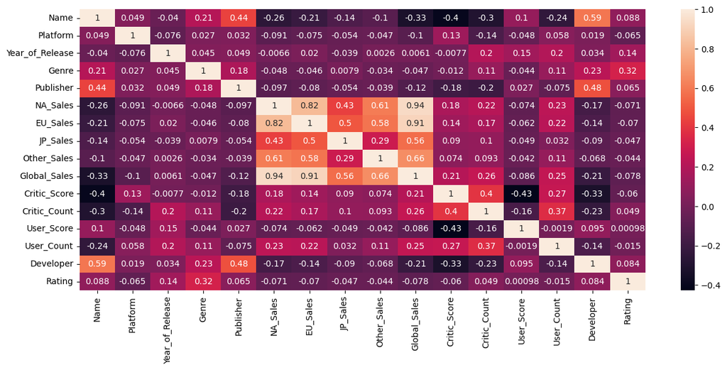

```python
plt.rcParams['figure.figsize'] = (15, 6)
sns.heatmap(dff.corr(),annot=True);
```

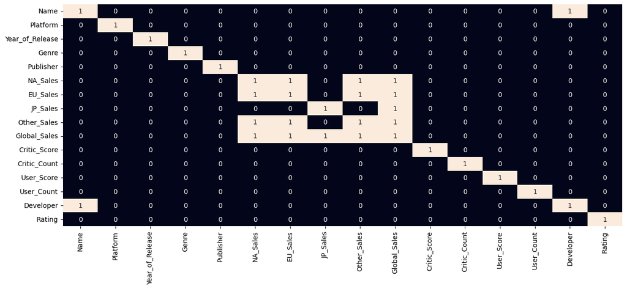

```python
#lets create a easier filter to read
filter1= dff.corr() > 0.5
sns.heatmap(filter1,annot=True,cbar=False);
```

```python
col1_correlation = df.corrwith(df['Global_Sales'])
sorted(round(col1_correlation,2), reverse=True)
```

```
[1.0, 0.94, 0.91, 0.66, 0.56, 0.26, 0.25, 0.21, 0.01]
```

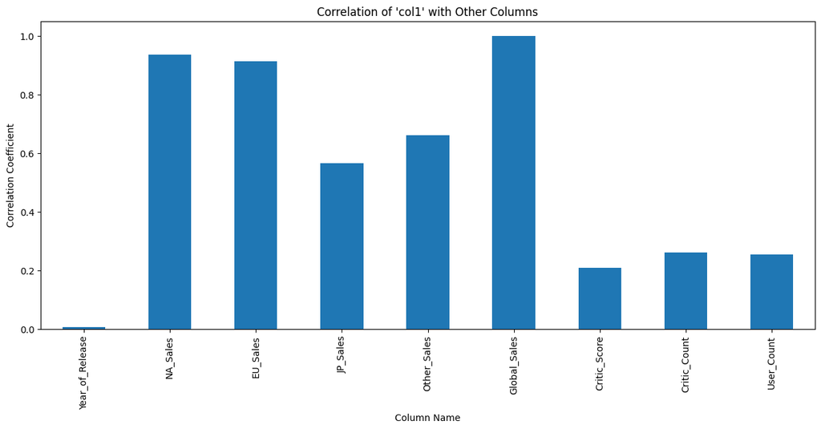

```python
col1_correlation.plot(kind='bar')
plt.title("Correlation of 'col1' with Other Columns")
plt.xlabel("Column Name")
plt.ylabel("Correlation Coefficient")
plt.show()
```

```python
high_correlations = col1_correlation[col1_correlation > 0.5]
high_correlations
```

```
NA_Sales        0.936098
EU_Sales        0.912676
JP_Sales        0.564225
Other_Sales     0.661175
Global_Sales    1.000000
dtype: float64
```

```python
dictt={"Name":list(high_correlations.keys()),"Score":list(high_correlations)}
high_correlations=pd.DataFrame(dictt)
high_correlations=high_correlations.drop(4)
```

```python
new_df=df[df["Global_Sales"] != 0] # will be using for predicting Global sales!
model_df=new_df[["NA_Sales","EU_Sales","JP_Sales","Other_Sales","Global_Sales"]]
```

```python
# defining x and y

x = model_df[["NA_Sales","EU_Sales","JP_Sales","Other_Sales"]]
y = model_df["Global_Sales"]

# Linear Regression Model
model=linear_model.LinearRegression()
# splitting the data
x_train, x_test, y_train, y_test = train_test_split(x, y, test_size = 0.2, random_state = 42)
Lin_reg=model.fit(x_train,y_train)
```

```python
y_prediction =  Lin_reg.predict(x_test)
```

```python
# Comparing predictions to test values
for i in range(len(y_prediction)):
    print("Predicted value:", round(y_prediction[i],0), "Actual value:", y_test.values[i])
```

```
Predicted value: 10.0 Actual value: 8
Predicted value: 3.0 Actual value: 2
Predicted value: 1.0 Actual value: 1
Predicted value: 2.0 Actual value: 2
Predicted value: 1.0 Actual value: 1
Predicted value: 3.0 Actual value: 3
Predicted value: 3.0 Actual value: 3
Predicted value: 2.0 Actual value: 1
Predicted value: 1.0 Actual value: 1
Predicted value: 6.0 Actual value: 6
Predicted value: 1.0 Actual value: 1
Predicted value: 2.0 Actual value: 2
Predicted value: 3.0 Actual value: 3
Predicted value: 1.0 Actual value: 1
Predicted value: 1.0 Actual value: 1
Predicted value: 1.0 Actual value: 1
Predicted value: 8.0 Actual value: 9
Predicted value: 3.0 Actual value: 3
Predicted value: 1.0 Actual value: 1
Predicted value: 2.0 Actual value: 2
Predicted value: 7.0 Actual value: 8
Predicted value: 1.0 Actual value: 1
Predicted value: 5.0 Actual value: 6
Predicted value: 2.0 Actual value: 2
Predicted value: 1.0 Actual value: 1
Predicted value: 1.0 Actual value: 1
Predicted value: 2.0 Actual value: 1
Predicted value: 2.0 Actual value: 2
Predicted value: 2.0 Actual value: 2
Predicted value: 6.0 Actual value: 7
Predicted value: 1.0 Actual value: 1
Predicted value: 1.0 Actual value: 1
Predicted value: 3.0 Actual value: 3
Predicted value: 2.0 Actual value: 1
Predicted value: 1.0 Actual value: 1
Predicted value: 1.0 Actual value: 2
Predicted value: 1.0 Actual value: 1
Predicted value: 1.0 Actual value: 1
Predicted value: 1.0 Actual value: 1
Predicted value: 1.0 Actual value: 1
```

[output cut: 208 more lines]

```
Predicted value: 2.0 Actual value: 1
Predicted value: 1.0 Actual value: 1
Predicted value: 2.0 Actual value: 2
Predicted value: 2.0 Actual value: 1
Predicted value: 1.0 Actual value: 1
Predicted value: 1.0 Actual value: 1
Predicted value: 3.0 Actual value: 3
Predicted value: 1.0 Actual value: 1
Predicted value: 1.0 Actual value: 1
Predicted value: 1.0 Actual value: 1
Predicted value: 4.0 Actual value: 4
Predicted value: 1.0 Actual value: 1
Predicted value: 1.0 Actual value: 2
Predicted value: 4.0 Actual value: 3
Predicted value: 2.0 Actual value: 2
```

```python
# importing r2_score module
from sklearn.metrics import r2_score
from sklearn.metrics import mean_squared_error
# predicting the accuracy score
score=r2_score(y_test,y_prediction)
print("r2 socre is ",score)
```

```
r2 socre is  0.9439198930512274
```

```python
high_correlations
```

|  | Name | Score |
| --- | --- | --- |
| 0 | NA_Sales | 0.936098 |
| 1 | EU_Sales | 0.912676 |
| 2 | JP_Sales | 0.564225 |
| 3 | Other_Sales | 0.661175 |

### B. What effect will the number of critics and users as well as their review scores have on the sales of Video games in North America, EU and Japan?

To find the effect of a group of variables on another group of variables, we used multivariate analysis techniques such as multiple regression analysis to answer this question.

We started off by assigning our predictors as X:

`X = dff[["Critic_Count","User_Count","User_Score","Critic_Score"]]`

Then we stated our target variables as mentioned in the question as :

`Y = dff[["NA_Sales","EU_Sales","JP_Sales"]]`

Initially we used the model of Linear regressor to find the R square score and it came out to be just **0.052** , The R-squared value of **0.052** indicates that the linear regression model explains only **5.2%** of the variance in the dependent variables. This means that there is a lot of unexplained variability in the data that the model is not capturing.

It is important to note that the R-squared value can be affected by many factors, such as the quality of the data, the choice of independent variables, and the complexity of the model. Therefore, it is not always a reliable measure of how well the model fits the data. It is often useful to use other metrics, such as mean squared error or cross-validation, to evaluate the performance of the model.

To counter this situation and without deep diving into granular levels we decided to proceed with a different regressor so we choose DecisionTreeRegressor. R-squared value for our decision tree regression model came out to be **0.99**, that's a very high value and indicates that the model explains almost all of the variance in the dependent variables.

```python
df.head()
```

|  | Name | Platform | Year_of_Release | Genre | Publisher | NA_Sales | EU_Sales | JP_Sales | Other_Sales | Global_Sales | Critic_Score | Critic_Count | User_Score | User_Count | Developer | Rating |
| --- | --- | --- | --- | --- | --- | --- | --- | --- | --- | --- | --- | --- | --- | --- | --- | --- |
| 0 | Wii Sports | Wii | 2006.0 | Sports | Nintendo | 41 | 28 | 3 | 8 | 82 | 76.0 | 51.0 | 8 | 322.0 | Nintendo | E |
| 2 | Mario Kart Wii | Wii | 2008.0 | Racing | Nintendo | 15 | 12 | 3 | 3 | 35 | 82.0 | 73.0 | 8.3 | 709.0 | Nintendo | E |
| 3 | Wii Sports Resort | Wii | 2009.0 | Sports | Nintendo | 15 | 10 | 3 | 2 | 32 | 80.0 | 73.0 | 8 | 192.0 | Nintendo | E |
| 6 | New Super Mario Bros. | DS | 2006.0 | Platform | Nintendo | 11 | 9 | 6 | 2 | 29 | 89.0 | 65.0 | 8.5 | 431.0 | Nintendo | E |
| 7 | Wii Play | Wii | 2006.0 | Misc | Nintendo | 13 | 9 | 2 | 2 | 28 | 58.0 | 41.0 | 6.6 | 129.0 | Nintendo | E |

```python
df2=dff[["Critic_Count","User_Count","User_Score","NA_Sales","EU_Sales","JP_Sales"]]
df2.head(5)
```

|  | Critic_Count | User_Count | User_Score | NA_Sales | EU_Sales | JP_Sales |
| --- | --- | --- | --- | --- | --- | --- |
| 0 | 51.0 | 322.0 | 0 | 41 | 28 | 3 |
| 2 | 73.0 | 709.0 | 1 | 15 | 12 | 3 |
| 3 | 73.0 | 192.0 | 0 | 15 | 10 | 3 |
| 6 | 65.0 | 431.0 | 2 | 11 | 9 | 6 |
| 7 | 41.0 | 129.0 | 3 | 13 | 9 | 2 |

```python
df2.dtypes
```

```
Critic_Count    float64
User_Count      float64
User_Score        int64
NA_Sales          int64
EU_Sales          int64
JP_Sales          int64
dtype: object
```

```python
df2.corr()
```

|  | Critic_Count | User_Count | User_Score | NA_Sales | EU_Sales | JP_Sales |
| --- | --- | --- | --- | --- | --- | --- |
| Critic_Count | 1.000000 | 0.365603 | -0.158186 | 0.218335 | 0.174547 | 0.100257 |
| User_Count | 0.365603 | 1.000000 | -0.001873 | 0.230780 | 0.223681 | 0.032236 |
| User_Score | -0.158186 | -0.001873 | 1.000000 | -0.074172 | -0.061792 | -0.049104 |
| NA_Sales | 0.218335 | 0.230780 | -0.074172 | 1.000000 | 0.819243 | 0.427183 |
| EU_Sales | 0.174547 | 0.223681 | -0.061792 | 0.819243 | 1.000000 | 0.495875 |
| JP_Sales | 0.100257 | 0.032236 | -0.049104 | 0.427183 | 0.495875 | 1.000000 |

Lets use a multi variate regression model

```python
dff.columns
```

```
Index(['Name', 'Platform', 'Year_of_Release', 'Genre', 'Publisher', 'NA_Sales',
       'EU_Sales', 'JP_Sales', 'Other_Sales', 'Global_Sales', 'Critic_Score',
       'Critic_Count', 'User_Score', 'User_Count', 'Developer', 'Rating'],
      dtype='object')
```

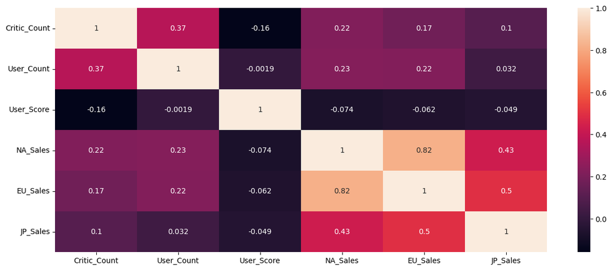

```python
sns.heatmap(df2.corr(),annot=True); # Here we can see the correlation of a variables
```

```python
# Separate dependent and independent variables
#  What effect will the number of critics and users as well as their review scores have on the sales of Video games in North America, EU and Japan?
X = dff[["Critic_Count","User_Count","User_Score","Critic_Score"]]
Y = dff[["NA_Sales","EU_Sales","JP_Sales"]]
np.random.seed(987)
# linear regression
model = linear_model.LinearRegression()

# Fit the model using the data
model.fit(X, Y)
Y_pred = model.predict(X)
Linear_r2 = r2_score(Y, Y_pred)
print('R-squared: ', Linear_r2)
```

```
R-squared:  0.05228061049255931
```

```python
X = dff[["Critic_Count","User_Count","User_Score","Critic_Score"]]
Y = dff[["NA_Sales","EU_Sales","JP_Sales"]]
np.random.seed(987)
# linear regression
model = DecisionTreeRegressor()

# Fit the model using the data
model.fit(X, Y)
Y_pred = model.predict(X)
Decision_r2 = r2_score(Y, Y_pred)
print('R-squared: ', Decision_r2)
```

```
R-squared:  0.9998502523159615
```

```python
Y_pred
```

```
array([[41., 28.,  3.],
       [15., 12.,  3.],
       [15., 10.,  3.],
       ...,
       [ 0.,  0.,  0.],
       [ 0.,  0.,  0.],
       [ 0.,  0.,  0.]])
```

### C. What propelled the choice of your regressor for this task? Aptly discuss with quantitative reasons!

A decision tree regression model may outperform a linear regression model due to its ability to capture non-linear relationships between variables. Linear regression models assume a linear relationship between variables, which may not hold true in some datasets. A decision tree model can handle non-linear relationships by partitioning the input space into rectangular regions, each with a different prediction, allowing it to capture complex relationships that a linear model may not. Additionally, decision trees are robust to outliers and can handle missing data. The resulting tree structure is also interpretable, providing insight into the important variables and their interactions. However, the performance of a regression model depends on the characteristics of the data, and it's important to try different models and evaluate their performance using appropriate metrics to determine the best model for the specific problem at hand.

The idea that the model used to fit the data initially which was **LinearRegression()** itself is a hyperparameter propelled me to think there might be a better regressor which can capture the non linear relationships between the low Pearson scored variables

```python
print('Linear Regression model R-squared: ', Linear_r2)
print('Decision Tree model R-squared: ', Decision_r2)
```

```
Linear Regression model R-squared:  0.05228061049255931
Decision Tree model R-squared:  0.9998502523159615
```

### D. Use all the relevant categorical variables in the Video Game Dataset as the target variable at each instance and determine which of the variables performed best in classifying the dataset. Explain your findings.

In this part of question , we analyzed the Video Game Sales dataset to determine which categorical variable performed best in classifying the data. The dataset contained the following categorical variables: ['Name', 'Platform', 'Genre', 'Publisher', 'User_Score', 'Developer', 'Rating']. We employed a Decision Tree classifier to evaluate each categorical variable as a target variable, while using the remaining columns as predictors.

To preprocess the dataset, we used LabelEncoder from the sklearn library, enabling efficient transformation of categorical variables. We then assessed the performance of each target variable by calculating feature_importances_, accuracy scores, and mean cross-validation accuracy scores. These metrics were utilized to evaluate the model's ability to fit the data without overfitting.

Our analysis revealed that the model fit the data well, as evidenced by the close similarity between mean cross-validation scores and actual classification accuracy scores. The model did not exhibit signs of overfitting. To identify the best categorical variable for classification, we examined the final results DataFrame, looking for the highest accuracy and mean cross-validation score, along with low feature importances for other variables.

The steps taken:

1. Filtered all the categorical variables within the dataset: ['Name', 'Platform', 'Genre', 'Publisher', 'User_Score', 'Developer', 'Rating'].
2. Used a Decision Tree classifier to classify one categorical variable at a time, while feeding the rest of the columns into predictors variable.
3. Employed LabelEncoder from the sklearn library to preprocess the dataset efficiently.
4. Calculated feature_importances_ and their ratios for each categorical variable to determine the best classifier.
5. Generated an accuracy score and a mean cross-validation accuracy score to check for overfitting.
6. Created a DataFrame of final results to analyze the performance of each categorical variable as a target.

```python
# Here is a list of all categorical variables within the current dataset
cat_cols = df.select_dtypes(include=['object']).columns.tolist() # Here is a list of categorical variables within the dataset
cat_cols
```

```
['Name', 'Platform', 'Genre', 'Publisher', 'User_Score', 'Developer', 'Rating']
```

### Classification for all relevant categorical variables

```python
le = LabelEncoder()
my_list = ['Name', 'Platform', 'Genre', 'Publisher', 'User_Score', 'Developer', 'Rating']

results_df = pd.DataFrame(columns=['Classified Column', 'Feature Importance', 'Accuracy', 'Mean CV Score'])

for i, current_element in enumerate(my_list):

    remaining_elements = my_list[:i] + my_list[i+1:]
    X = df.drop(current_element, axis=1)
    y = df[current_element]

    # Encoding the data
    encoded_df = df.copy()
    for var in my_list:
        encoded_df[var] = le.fit_transform(encoded_df[var].astype('category'))

    X = encoded_df.drop(current_element, axis=1)
    y = encoded_df[current_element]

    # Performing cross-validation to generate mean cross validation score
    scores = cross_val_score(DecisionTreeClassifier(), X, y, cv=5)
    mean_cv_score = scores.mean()

    X_train, X_test, y_train, y_test = train_test_split(X, y, test_size=0.2, random_state=42)

    model = DecisionTreeClassifier()
    model.fit(X_train, y_train)

    y_pred = model.predict(X_test)

    # Getting feature importances to find the ratios
    importances = model.feature_importances_

    # Creating a dictionary of feature names and importances
    feature_importances = dict(zip(X.columns, importances))

    # Finding accuracy
    accuracy = accuracy_score(y_test, y_pred)
    print("\n=========================================")
    print(f"Classification Done for Column = \"{current_element}\"")
    print(f"Classification Accuracy = {accuracy}")
    print(f"Mean CV Score = {mean_cv_score}\n")

    # Saving results to dataframe
    for feature, importance in sorted(feature_importances.items(), key=lambda x: x[1], reverse=True):
        results_df = results_df.append({'Classified Column': current_element, 'Feature': feature, 'Feature Importance': round(importance, 3), 'Accuracy': round(accuracy, 2), 'Mean CV Score': round(mean_cv_score, 2)}, ignore_index=True)
        print(f"{feature}: {importance}")

# Results are saved in results_df dataframe
```

```
=========================================
Classification Done for Column = "Name"
Classification Accuracy = 0.24395604395604395
Mean CV Score = 0.27472527472527475

Developer: 0.16005615626629957
Year_of_Release: 0.15144161581933854
Critic_Score: 0.13894060266710115
User_Score: 0.10319725785866991
User_Count: 0.10110610464704883
Critic_Count: 0.08323372209831587
Publisher: 0.07199726603874752
Rating: 0.0575756112950473
Genre: 0.05285457568326033
Platform: 0.042183977290933865
Global_Sales: 0.01980434129159403
NA_Sales: 0.010344945580346522
EU_Sales: 0.0044545281722687576
JP_Sales: 0.002259650560174555
Other_Sales: 0.0005496447308532701

=========================================
Classification Done for Column = "Platform"
Classification Accuracy = 0.3567765567765568
Mean CV Score = 0.33377289377289376

Year_of_Release: 0.16952492585908088
User_Count: 0.13803414334212172
Critic_Count: 0.13182287274638224
Critic_Score: 0.09196786010692518
User_Score: 0.0905190733430265
Name: 0.08917233757678864
Developer: 0.08168714783633556
Publisher: 0.07698771588153942
Genre: 0.05713457373177555
Rating: 0.037467880119048246
Global_Sales: 0.02625096792019923
NA_Sales: 0.004411468420866727
EU_Sales: 0.0025593471534385527
JP_Sales: 0.0017492065034809656
```

[output cut: 91 more lines]

```
Genre: 0.20008024195292606
Name: 0.16362663339403682
Publisher: 0.10508894156830857
User_Count: 0.09951751865681192
Developer: 0.09299038588328859
User_Score: 0.07248466999443005
Critic_Score: 0.07111754111453787
Year_of_Release: 0.07102873314904252
Critic_Count: 0.058543326273286615
Platform: 0.05319798015106642
Global_Sales: 0.009501467418342286
NA_Sales: 0.0014303189584214688
EU_Sales: 0.0013922414855007648
JP_Sales: 0.0
Other_Sales: 0.0
```

```python
results_df
```

|  | Classified Column | Feature Importance | Accuracy | Mean CV Score | Feature |
| --- | --- | --- | --- | --- | --- |
| 0 | Name | 0.160 | 0.24 | 0.27 | Developer |
| 1 | Name | 0.151 | 0.24 | 0.27 | Year_of_Release |
| 2 | Name | 0.139 | 0.24 | 0.27 | Critic_Score |
| 3 | Name | 0.103 | 0.24 | 0.27 | User_Score |
| 4 | Name | 0.101 | 0.24 | 0.27 | User_Count |
| ... | ... | ... | ... | ... | ... |
| 100 | Rating | 0.010 | 0.68 | 0.61 | Global_Sales |
| 101 | Rating | 0.001 | 0.68 | 0.61 | NA_Sales |
| 102 | Rating | 0.001 | 0.68 | 0.61 | EU_Sales |
| 103 | Rating | 0.000 | 0.68 | 0.61 | JP_Sales |
| 104 | Rating | 0.000 | 0.68 | 0.61 | Other_Sales |

105 rows × 5 columns

### E. How did you check whether your models did not overfit?

another potential approach that can be used for checking model overfit is creating a mode learning curve for test and train data , but cv score was selected for this approach

### F. Can your classification models be deployed in practice based on their performances? Explain.

In conclusion, we analyzed the Video Game dataset to classify different categorical variables using a Decision Tree Classifier. We considered the following categorical variables as target variables: 'Name', 'Platform', 'Genre', 'Publisher', 'User_Score', 'Developer', and 'Rating'. For each classification task, we calculated the accuracy and mean cross-validation score to evaluate the model's performance and ensure that it was not overfitting.

Our findings revealed that the best performing categorical variable for classification was 'Rating', with an accuracy of 68% and a mean cross-validation score of 61%. The most important feature contributing to this classification was 'Genre', with a feature importance of 20.0%.

These results suggest that the 'Rating' variable is the most effective in classifying the dataset. It is essential to note that although the model performance may not be perfect, it provides a reasonable starting point for further investigation and optimization. To improve the classification performance, one could explore other machine learning algorithms, feature engineering techniques, or incorporate additional data sources.

```python
results_df=results_df.sort_values(["Accuracy", 'Mean CV Score'],ascending=False)
results_df.head(10)
```

|  | Classified Column | Feature Importance | Accuracy | Mean CV Score | Feature |
| --- | --- | --- | --- | --- | --- |
| 90 | Rating | 0.200 | 0.68 | 0.61 | Genre |
| 91 | Rating | 0.164 | 0.68 | 0.61 | Name |
| 92 | Rating | 0.105 | 0.68 | 0.61 | Publisher |
| 93 | Rating | 0.100 | 0.68 | 0.61 | User_Count |
| 94 | Rating | 0.093 | 0.68 | 0.61 | Developer |
| 95 | Rating | 0.072 | 0.68 | 0.61 | User_Score |
| 96 | Rating | 0.071 | 0.68 | 0.61 | Critic_Score |
| 97 | Rating | 0.071 | 0.68 | 0.61 | Year_of_Release |
| 98 | Rating | 0.059 | 0.68 | 0.61 | Critic_Count |
| 99 | Rating | 0.053 | 0.68 | 0.61 | Platform |

```python
evaluation_metric=results_df.groupby(["Classified Column","Accuracy","Mean CV Score","Feature"]).max("Feature Importance")
evaluation_metric.sort_values(["Accuracy","Mean CV Score","Feature Importance"],ascending=False)
```

| Classified Column | Accuracy | Mean CV Score | Feature | Feature Importance |
| --- | --- | --- | --- | --- |
| Rating | 0.68 | 0.61 | Genre | 0.200 |
|  |  |  | Name | 0.164 |
|  |  |  | Publisher | 0.105 |
|  |  |  | User_Count | 0.100 |
|  |  |  | Developer | 0.093 |
| ... | ... | ... | ... | ... |
| User_Score | 0.04 | 0.04 | Global_Sales | 0.020 |
|  |  |  | NA_Sales | 0.006 |
|  |  |  | EU_Sales | 0.004 |
|  |  |  | JP_Sales | 0.001 |
|  |  |  | Other_Sales | 0.000 |

105 rows × 1 columns

```python
best_variable = evaluation_metric.sort_values(["Accuracy","Mean CV Score","Feature Importance"],ascending=False).iloc[0]
best_variable.name[0]
print(f"The best performing categorical variable is '{best_variable.name[0]}' with an accuracy of {best_variable.name[1]:.1%} and a mean CV score of {best_variable.name[2]:.1%}.")
print(f"The most important feature contributing to this classification is '{best_variable.name[3]}', with a feature importance of {best_variable['Feature Importance']:.1%}.")
```

```
The best performing categorical variable is 'Rating' with an accuracy of 68.0% and a mean CV score of 61.0%.
The most important feature contributing to this classification is 'Genre', with a feature importance of 20.0%.
```